# NLP_Project

## **Problem Statement**

### **Business Context**

In today's dynamic business landscape, organizations are increasingly recognizing the pivotal role customer feedback plays in shaping the trajectory of their products and services. The ability to **swiftly and effectively respond to customer input** not only fosters enhanced customer experiences but also serves as a catalyst for growth, prolonged customer engagement, and the nurturing of lifetime value relationships.

As a dedicated Product Manager or Product Analyst, staying attuned to the voice of your customers is not just a best practice; it's a strategic imperative.

While your organization may be inundated with a wealth of customer-generated feedback and support tickets, your role entails much more than just processing these inputs. To make your efforts in managing customer experience and expectations truly impactful, you need a structured approach – a method that allows you to discern the most pressing issues, set priorities, and allocate resources judiciously.

One of the most effective strategies at your disposal as an organization is to harness the power of automated Support Ticket Categorization - **done in the modern day using Large Language Models and Generative AI.**

### **Objective**

Develop a Generative AI application using a Large Language Model to **automate the classification and processing of support tickets.** The application will aim to predict ticket categories, assign priority, suggest estimated resolution times, generate responses based on sentiment analysis, and store the results in a structured DataFrame.

## **Please read the instructions carefully before starting the project.**

This is a commented Python Notebook file in which all the instructions and tasks to be performed are mentioned.

- Blanks '_______' are provided in the notebook that needs to be filled with an appropriate code to get the correct result. With every '_______' blank, there is a comment that briefly describes what needs to be filled in the blank space.
- Identify the task to be performed correctly, and only then proceed to write the required code.
- Please run the codes in a sequential manner from the beginning to avoid any unnecessary errors.
- Add the results/observations (wherever mentioned) derived from the analysis in the presentation and submit the same. Any mathematical or computational details which are a graded part of the project can be included in the Appendix section of the presentation.

## **Installing and Importing Necessary Libraries and Dependencies**

```python
# Installation for GPU llama-cpp-python
!CMAKE_ARGS="-DLLAMA_CUBLAS=on" FORCE_CMAKE=1 pip install llama-cpp-python --force-reinstall --upgrade --no-cache-dir -q
```

[output not shown]

```python
# Install the hugging face hub
!pip install huggingface_hub -q
```

```python
# Importing library for data manipulation
import pandas as pd

# Function to download the model from the Hugging Face model hub
from huggingface_hub import hf_hub_download

# Importing the Llama class from the llama_cpp module
from llama_cpp import Llama

# Importing the json module
import json

#Importing the plotting libraries
import matplotlib.pyplot as plt
```

## **Loading the Dataset**

```python
RunningInCOLAB = 'google.colab' in str(get_ipython()) if hasattr(__builtins__,'__IPYTHON__') else False

if RunningInCOLAB:
  #We are running this on Google Colab
  from google.colab import drive
  drive.mount('/content/drive')
  project_dir='/content/drive/MyDrive/Tuhin/AI-ML Course - UT Austin/Projects/9-Natural Language Processing' #Our project directory is mounted here
else:
  #We are running in local machine
  project_dir='.' #Our project directory is local directory
```

```python
# Read the CSV file
csv_data = f'{project_dir}/Support_ticket_text_data_mid_term.csv'
data = pd.read_csv(csv_data)
```

## **Data Overview**

```python
# Check the first 5 rows of data
data.head(5)
```

|  | support_tick_id | support_ticket_text |
| --- | --- | --- |
| 0 | ST2023-006 | My internet connection has significantly slowe... |
| 1 | ST2023-007 | Urgent help required! My laptop refuses to sta... |
| 2 | ST2023-008 | I've accidentally deleted essential work docum... |
| 3 | ST2023-009 | Despite being in close proximity to my Wi-Fi r... |
| 4 | ST2023-010 | My smartphone battery is draining rapidly, eve... |

```python
# Check the shape of the data
print(data.shape)
```

```
(21, 2)
```

```python
# Check for missing values in the data

data.isnull().sum()
```

```
support_tick_id        0
support_ticket_text    0
dtype: int64
```

## **Model Building**

### Loading the model

```python
model_name_or_path = "TheBloke/Llama-2-13B-chat-GGUF" #Llama 2 with 13B parameters
model_basename = "llama-2-13b-chat.Q5_K_M.gguf" # the model is in gguf format - quantized with 5 bit
```

```python
# Using hf_hub_download to download a model from the Hugging Face model hub
# The repo_id parameter specifies the model name or path in the Hugging Face repository
# The filename parameter specifies the name of the file to download

model_path = hf_hub_download(
    repo_id = model_name_or_path,    # complete the code to mentioned the repo_id
    filename = model_basename    # complete the code to mentioned the filename
)
```

```python
# Create an instance of the 'Llama' class with specified parameters

lcpp_llm = Llama(
    model_path=model_path,
    n_threads=None,   # CPU cores
    n_batch=1024,      # Should be between 1 and n_ctx, consider the amount of VRAM in your GPU.
    n_gpu_layers=-1,  # Change this value based on your model and your GPU VRAM pool.
    n_ctx=1024,        # Context window
)
```

[output not shown]

[output cut: 32 more lines]

[output not shown]

### Defining Model Response Parameters

```python
def generate_llama_response(row, total, instruction):

    review = row['support_ticket_text']
    current = row.name + 1

    # System message explicitly instructing not to include the review text
    system_message = """
        [INST]<<SYS>>
        {}
        <</SYS>>[/INST]
    """.format(instruction)

    # Combine user_prompt and system_message to create the prompt
    prompt = f"{review}\n{system_message}"

    print(f'\n=> Generating response for row {current} of {total} >>>>')
    # Generate a response from the LLaMA model
    response = lcpp_llm(
        prompt=prompt,
        max_tokens=1024,
        temperature=0.01,
        top_p=0.95,
        repeat_penalty=1.2,
        top_k=50,
        stop=['INST'],
        echo=False,
        seed=42,
    )

    # Extract the sentiment from the response
    response_text = ""
    for choice in response["choices"]:
      response_text = response_text + ' ' + choice["text"]
    return response_text
```

## **Task 1: Ticket Categorization**

```python
# create a copy of the data
data_1 = data.copy()
```

```python
## Complete the prompt to get the desired output
instruction_1 = """
    You are a customer support executive for computer related problem. Your job is to create ticket categories based on the problem given by the user.
    The categories are : 'technical issues', 'hardware issues' and 'data recovery'.
    Please answer only with one possible category name.
    Do not include any other text other than the category text.
"""
```

```python
data_1['llama_response'] = data_1.apply(generate_llama_response, axis=1, args=(len(data_1), instruction_1))
```

```
=> Generating response for row 1 of 21 >>>>
```

[output not shown]

```
=> Generating response for row 2 of 21 >>>>
```

[output not shown]

```
=> Generating response for row 3 of 21 >>>>
```

[output not shown]

```
=> Generating response for row 4 of 21 >>>>
```

[output not shown]

```
=> Generating response for row 5 of 21 >>>>
```

[output not shown]

```
=> Generating response for row 6 of 21 >>>>
```

[output not shown]

```
=> Generating response for row 7 of 21 >>>>
```

[output not shown]

```
=> Generating response for row 8 of 21 >>>>
```

[output not shown]

```
=> Generating response for row 9 of 21 >>>>
```

[output not shown]

```
=> Generating response for row 10 of 21 >>>>
```

[output not shown]

```
=> Generating response for row 11 of 21 >>>>
```

[output not shown]

```
=> Generating response for row 12 of 21 >>>>
```

[output not shown]

```
=> Generating response for row 13 of 21 >>>>
```

[output not shown]

```
=> Generating response for row 14 of 21 >>>>
```

[output not shown]

```
=> Generating response for row 15 of 21 >>>>
```

[output not shown]

```
=> Generating response for row 16 of 21 >>>>
```

[output not shown]

```
=> Generating response for row 17 of 21 >>>>
```

[output not shown]

```
=> Generating response for row 18 of 21 >>>>
```

[output not shown]

```
=> Generating response for row 19 of 21 >>>>
```

[output not shown]

```
=> Generating response for row 20 of 21 >>>>
```

[output not shown]

```
=> Generating response for row 21 of 21 >>>>
```

[output not shown]

```python
# Write the code to check the first five rows of the data to confirm whether the new column has been added
data_1.head(5)
```

|  | support_tick_id | support_ticket_text | llama_response |
| --- | --- | --- | --- |
| 0 | ST2023-006 | My internet connection has significantly slowe... | Sure! Based on your message, the category na... |
| 1 | ST2023-007 | Urgent help required! My laptop refuses to sta... | Sure! Based on the information provided, the... |
| 2 | ST2023-008 | I've accidentally deleted essential work docum... | Sure! Based on your issue, the category name... |
| 3 | ST2023-009 | Despite being in close proximity to my Wi-Fi r... | Sure! Based on your description of a persist... |
| 4 | ST2023-010 | My smartphone battery is draining rapidly, eve... | Sure! Based on your description, I would cat... |

```python
def extract_category(model_response):
    if 'technical issues' in model_response.lower():
        return 'Technical issues'
    elif 'hardware issues' in model_response.lower():
        return 'Hardware issues'
    elif 'data recovery' in model_response.lower():
        return 'Data recovery'
```

```python
data_1['Category'] = data_1['llama_response'].apply(extract_category)
data_1['Category'].head()
```

```
0    Technical issues
1     Hardware issues
2       Data recovery
3    Technical issues
4     Hardware issues
Name: Category, dtype: object
```

```python
#Drop the llama response column
final_data_1 = data_1.drop(['llama_response'], axis=1)
final_data_1.head()
```

|  | support_tick_id | support_ticket_text | Category |
| --- | --- | --- | --- |
| 0 | ST2023-006 | My internet connection has significantly slowe... | Technical issues |
| 1 | ST2023-007 | Urgent help required! My laptop refuses to sta... | Hardware issues |
| 2 | ST2023-008 | I've accidentally deleted essential work docum... | Data recovery |
| 3 | ST2023-009 | Despite being in close proximity to my Wi-Fi r... | Technical issues |
| 4 | ST2023-010 | My smartphone battery is draining rapidly, eve... | Hardware issues |

## **Task 2: Ticket Categorization and Returning Structured Output**

```python
# create a copy of the data
data_2 = data.copy()
```

```python
## Complete the prompt to get the desired output
instruction_2 = """
    You are a customer support executive for computer related problem.
    Your job is to create ticket categories based on the problem given by the user.
    The categories are : 'technical issues', 'hardware issues' and 'data recovery'.
    Please answer using following json structure:
    { 'Category' : '' }
    Do not include any other text in the output except the JSON.
"""
```

```python
data_2['llama_response'] = data_2.apply(generate_llama_response, axis=1, args=(len(data_2), instruction_2))
```

```
Llama.generate: prefix-match hit
```

```
=> Generating response for row 1 of 21 >>>>
```

[output not shown]

```
=> Generating response for row 2 of 21 >>>>
```

[output not shown]

```
=> Generating response for row 3 of 21 >>>>
```

[output not shown]

```
=> Generating response for row 4 of 21 >>>>
```

[output not shown]

```
=> Generating response for row 5 of 21 >>>>
```

[output not shown]

```
=> Generating response for row 6 of 21 >>>>
```

[output not shown]

```
=> Generating response for row 7 of 21 >>>>
```

[output not shown]

```
=> Generating response for row 8 of 21 >>>>
```

[output not shown]

```
=> Generating response for row 9 of 21 >>>>
```

[output not shown]

```
=> Generating response for row 10 of 21 >>>>
```

[output not shown]

```
=> Generating response for row 11 of 21 >>>>
```

[output not shown]

```
=> Generating response for row 12 of 21 >>>>
```

[output not shown]

```
=> Generating response for row 13 of 21 >>>>
```

[output not shown]

```
=> Generating response for row 14 of 21 >>>>
```

[output not shown]

```
=> Generating response for row 15 of 21 >>>>
```

[output not shown]

```
=> Generating response for row 16 of 21 >>>>
```

[output not shown]

```
=> Generating response for row 17 of 21 >>>>
```

[output not shown]

```
=> Generating response for row 18 of 21 >>>>
```

[output not shown]

```
=> Generating response for row 19 of 21 >>>>
```

[output not shown]

```
=> Generating response for row 20 of 21 >>>>
```

[output not shown]

```
=> Generating response for row 21 of 21 >>>>
```

[output not shown]

```python
# Write the code to check the first five rows of the data to confirm whether the new column has been added
data_2.head(5)
```

|  | support_tick_id | support_ticket_text | llama_response |
| --- | --- | --- | --- |
| 0 | ST2023-006 | My internet connection has significantly slowe... | { "Category": "technical issues" } |
| 1 | ST2023-007 | Urgent help required! My laptop refuses to sta... | { "Category": "hardware issues" } |
| 2 | ST2023-008 | I've accidentally deleted essential work docum... | { "Category": "data recovery" } |
| 3 | ST2023-009 | Despite being in close proximity to my Wi-Fi r... | { "Category": "technical issues" } |
| 4 | ST2023-010 | My smartphone battery is draining rapidly, eve... | { "Category": "technical issues" } |

```python
# defining a function to parse the JSON output from the model
def extract_json_data(json_str):
    try:
        # Find the indices of the opening and closing curly braces
        json_start = json_str.find('{')
        json_end = json_str.rfind('}')

        if json_start != -1 and json_end != -1:
            extracted_category = json_str[json_start:json_end + 1]  # Extract the JSON object
            data_dict = json.loads(extracted_category)
            return data_dict
        else:
            print(f"Warning: JSON object not found in response: {json_str}")
            return {}
    except json.JSONDecodeError as e:
        print(f"Error parsing JSON: {e}")
        return {}

#Define a function to convert a string to title case
def to_title_case(str):
  return str.title()
```

```python
#Extract the json body
data_2['llama_response_parsed'] = data_2['llama_response'].apply(extract_json_data)
data_2['llama_response_parsed'].head()
```

```
0    {'Category': 'technical issues'}
1     {'Category': 'hardware issues'}
2       {'Category': 'data recovery'}
3    {'Category': 'technical issues'}
4    {'Category': 'technical issues'}
Name: llama_response_parsed, dtype: object
```

```python
#normalize json into panda column
llama_response_parsed_df_2 = pd.json_normalize(data_2['llama_response_parsed'])
#Convert the Category values to title case
llama_response_parsed_df_2['Category'] = llama_response_parsed_df_2['Category'].apply(to_title_case)
#Show first 5 rows
llama_response_parsed_df_2.head()
```

|  | Category |
| --- | --- |
| 0 | Technical Issues |
| 1 | Hardware Issues |
| 2 | Data Recovery |
| 3 | Technical Issues |
| 4 | Technical Issues |

```python
#Add the extracted json column to original dataset
data_with_parsed_model_output_2 = pd.concat([data_2, llama_response_parsed_df_2], axis=1)
data_with_parsed_model_output_2.head()
```

[output not shown]

```python
#Drop the intermediate columns
final_data_2 = data_with_parsed_model_output_2.drop(['llama_response','llama_response_parsed'], axis=1)
final_data_2.head()
```

[output not shown]

## **Task 3: Ticket Categorization, Creating Tags, and Returning Structured Output**

```python
# create a copy of the data
data_3 = data.copy()
```

```python
## Complete the prompt to get the desired output
instruction_3 = """
    You are a customer support executive for computer related problem.
    Your job is to create ticket categories and tags based on the problem given by the user.
    The categories are : 'technical issues', 'hardware issues' and 'data recovery'.
    Tags are keywords present in the problem statements.
    Example of tags are: hardware, software, restart, weak wifi, data loss, battery issue and so on.
    Please answer using following json structure:
    { "Category" : "", "Tags" : ["",...] }
    Do not include any other text in the output except the JSON.
  """
```

```python
data_3['llama_response'] = data_3.apply(generate_llama_response, axis=1, args=(len(data_3), instruction_3))
```

```
Llama.generate: prefix-match hit
```

```
=> Generating response for row 1 of 21 >>>>
```

[output not shown]

```
=> Generating response for row 2 of 21 >>>>
```

[output not shown]

```
=> Generating response for row 3 of 21 >>>>
```

[output not shown]

```
=> Generating response for row 4 of 21 >>>>
```

[output not shown]

```
=> Generating response for row 5 of 21 >>>>
```

[output not shown]

```
=> Generating response for row 6 of 21 >>>>
```

[output not shown]

```
=> Generating response for row 7 of 21 >>>>
```

[output not shown]

```
=> Generating response for row 8 of 21 >>>>
```

[output not shown]

```
=> Generating response for row 9 of 21 >>>>
```

[output not shown]

```
=> Generating response for row 10 of 21 >>>>
```

[output not shown]

```
=> Generating response for row 11 of 21 >>>>
```

[output not shown]

```
=> Generating response for row 12 of 21 >>>>
```

[output not shown]

```
=> Generating response for row 13 of 21 >>>>
```

[output not shown]

```
=> Generating response for row 14 of 21 >>>>
```

[output not shown]

```
=> Generating response for row 15 of 21 >>>>
```

[output not shown]

```
=> Generating response for row 16 of 21 >>>>
```

[output not shown]

```
=> Generating response for row 17 of 21 >>>>
```

[output not shown]

```
=> Generating response for row 18 of 21 >>>>
```

[output not shown]

```
=> Generating response for row 19 of 21 >>>>
```

[output not shown]

```
=> Generating response for row 20 of 21 >>>>
```

[output not shown]

```
=> Generating response for row 21 of 21 >>>>
```

[output not shown]

```python
# Write the code to check the first five rows of the data to confirm whether the new column has been added
data_3.head(5)
```

|  | support_tick_id | support_ticket_text | llama_response |
| --- | --- | --- | --- |
| 0 | ST2023-006 | My internet connection has significantly slowe... | { "Category": "technical issues", "Tags": ["... |
| 1 | ST2023-007 | Urgent help required! My laptop refuses to sta... | { "Category": "hardware issues", "Tags": ["r... |
| 2 | ST2023-008 | I've accidentally deleted essential work docum... | { "Category": "data recovery", "Tags": ["dat... |
| 3 | ST2023-009 | Despite being in close proximity to my Wi-Fi r... | { "Category": "technical issues", "Tags": ["... |
| 4 | ST2023-010 | My smartphone battery is draining rapidly, eve... | { "Category": "hardware issues", "Tags": ["b... |

```python
#Extract json body from the response
data_3['llama_response_parsed'] = data_3['llama_response'].apply(extract_json_data)
data_3['llama_response_parsed'].head()
```

```
0    {'Category': 'technical issues', 'Tags': ['int...
1    {'Category': 'hardware issues', 'Tags': ['rest...
2    {'Category': 'data recovery', 'Tags': ['data l...
3    {'Category': 'technical issues', 'Tags': ['wea...
4    {'Category': 'hardware issues', 'Tags': ['batt...
Name: llama_response_parsed, dtype: object
```

```python
#Convert json object to panda dataset
llama_response_parsed_df_3 = pd.json_normalize(data_3['llama_response_parsed'])
llama_response_parsed_df_3.head()
```

|  | Category | Tags |
| --- | --- | --- |
| 0 | technical issues | [internet connection, disconnections, slow speed] |
| 1 | hardware issues | [restart, hardware] |
| 2 | data recovery | [data loss, essential work documents] |
| 3 | technical issues | [weak wifi, signal strength] |
| 4 | hardware issues | [battery issue] |

```python
#Add extracted json column to dataset
data_with_parsed_model_output_3 = pd.concat([data_3, llama_response_parsed_df_3], axis=1)
#Convert the Category  values to title case
llama_response_parsed_df_3['Category'] = llama_response_parsed_df_2['Category'].apply(to_title_case)
#Show first 5 rows
data_with_parsed_model_output_3.head()
```

[output not shown]

```python
## Drop llama_response and llama_response_parsed variables
final_data_3 = data_with_parsed_model_output_3.drop(['llama_response','llama_response_parsed'], axis=1)
final_data_3.head()
```

|  | support_tick_id | support_ticket_text | Category | Tags |
| --- | --- | --- | --- | --- |
| 0 | ST2023-006 | My internet connection has significantly slowe... | Technical Issues | [internet connection, disconnections, slow speed] |
| 1 | ST2023-007 | Urgent help required! My laptop refuses to sta... | Hardware Issues | [restart, hardware] |
| 2 | ST2023-008 | I've accidentally deleted essential work docum... | Data Recovery | [data loss, essential work documents] |
| 3 | ST2023-009 | Despite being in close proximity to my Wi-Fi r... | Technical Issues | [weak wifi, signal strength] |
| 4 | ST2023-010 | My smartphone battery is draining rapidly, eve... | Technical Issues | [battery issue] |

## **Task 4 - Ticket Categorization, Creating Tags, Assigning Priority, and Returning Structured Output**

```python
# create a copy of the data
data_4 = data.copy()
```

```python
## Complete the prompt to get the desired output
instruction_4 = """
    You are a customer support executive for computer related problem.
    Your job is to create ticket categories , tags and priority based on the problem given by the user.
    The categories are : 'technical issues', 'hardware issues' and 'data recovery'.
    Tags are keywords present in the problem statements.
    Example of tags are: hardware, software, restart, weak wifi, data loss, battery issue and so on.
    Prorities are: High, Medium or Low.
    Please answer using following json structure:
    { "Category" : "", "Tags" : ["",...], "Priority" : "" }
    Do not include any other text in the output except the JSON.
"""
```

```python
# complete the code to create a new column llama_response'
# by applying the generate_llama_response function to each ticket in the 'support_ticket_text' column of the DataFrame 'data_4'
data_4['llama_response'] = data_4.apply(generate_llama_response, axis=1, args=(len(data_4), instruction_4))
```

```
=> Generating response for row 1 of 21 >>>>
```

[output not shown]

```
=> Generating response for row 2 of 21 >>>>
```

[output not shown]

```
=> Generating response for row 3 of 21 >>>>
```

[output not shown]

```
=> Generating response for row 4 of 21 >>>>
```

[output not shown]

```
=> Generating response for row 5 of 21 >>>>
```

[output not shown]

```
=> Generating response for row 6 of 21 >>>>
```

[output not shown]

```
=> Generating response for row 7 of 21 >>>>
```

[output not shown]

```
=> Generating response for row 8 of 21 >>>>
```

[output not shown]

```
=> Generating response for row 9 of 21 >>>>
```

[output not shown]

```
=> Generating response for row 10 of 21 >>>>
```

[output not shown]

```
=> Generating response for row 11 of 21 >>>>
```

[output not shown]

```
=> Generating response for row 12 of 21 >>>>
```

[output not shown]

```
=> Generating response for row 13 of 21 >>>>
```

[output not shown]

```
=> Generating response for row 14 of 21 >>>>
```

[output not shown]

```
=> Generating response for row 15 of 21 >>>>
```

[output not shown]

```
=> Generating response for row 16 of 21 >>>>
```

[output not shown]

```
=> Generating response for row 17 of 21 >>>>
```

[output not shown]

```
=> Generating response for row 18 of 21 >>>>
```

[output not shown]

```
=> Generating response for row 19 of 21 >>>>
```

[output not shown]

```
=> Generating response for row 20 of 21 >>>>
```

[output not shown]

```
=> Generating response for row 21 of 21 >>>>
```

[output not shown]

```python
# Write the code to check the first five rows of the data to confirm whether the new column has been added
data_4.head(5)
```

|  | support_tick_id | support_ticket_text | llama_response |
| --- | --- | --- | --- |
| 0 | ST2023-006 | My internet connection has significantly slowe... | { "Category": "technical issues", "Tags": ["... |
| 1 | ST2023-007 | Urgent help required! My laptop refuses to sta... | { "Category": "Hardware Issues", "Tags": ["r... |
| 2 | ST2023-008 | I've accidentally deleted essential work docum... | { "Category": "Data Recovery", "Tags": ["dat... |
| 3 | ST2023-009 | Despite being in close proximity to my Wi-Fi r... | { "Category": "technical issues", "Tags": ["... |
| 4 | ST2023-010 | My smartphone battery is draining rapidly, eve... | { "Category": "hardware issues", "Tags": ["b... |

```python
## Complete the code to apply the extract_json_data function on the llama_response column to create a new column called llama_response_parsed
data_4['llama_response_parsed'] = data_4['llama_response'].apply(extract_json_data)
data_4['llama_response_parsed'].head()
```

```
0    {'Category': 'technical issues', 'Tags': ['int...
1    {'Category': 'Hardware Issues', 'Tags': ['rest...
2    {'Category': 'Data Recovery', 'Tags': ['data l...
3    {'Category': 'technical issues', 'Tags': ['wea...
4    {'Category': 'hardware issues', 'Tags': ['batt...
Name: llama_response_parsed, dtype: object
```

```python
## Complete the code to apply the json_normalize on llama_response_parsed variable
llama_response_parsed_df_4 = pd.json_normalize(data_4['llama_response_parsed'])
#Convert the Category  and priority values to title case
llama_response_parsed_df_4['Category'] = llama_response_parsed_df_4['Category'].apply(to_title_case)
llama_response_parsed_df_4['Priority'] = llama_response_parsed_df_4['Priority'].apply(to_title_case)
#Show first 5 rows
llama_response_parsed_df_4.head()
```

|  | Category | Tags | Priority |
| --- | --- | --- | --- |
| 0 | Technical Issues | [internet, disconnection, frequent] | High |
| 1 | Hardware Issues | [restart, hardware] | High |
| 2 | Data Recovery | [data loss, essential work documents] | High |
| 3 | Technical Issues | [weak wifi, signal strength] | Medium |
| 4 | Hardware Issues | [battery, rapidly, draining] | Medium |

```python
## Complete the code to concat data_4 and llama_response_parsed_df_4
data_with_parsed_model_output_4 = pd.concat([data_4, llama_response_parsed_df_4], axis=1)
data_with_parsed_model_output_4.head()
```

|  | support_tick_id | support_ticket_text | llama_response | llama_response_parsed | Category | Tags | Priority |
| --- | --- | --- | --- | --- | --- | --- | --- |
| 0 | ST2023-006 | My internet connection has significantly slowe... | { "Category": "technical issues", "Tags": ["... | {'Category': 'technical issues', 'Tags': ['int... | Technical Issues | [internet, disconnection, frequent] | High |
| 1 | ST2023-007 | Urgent help required! My laptop refuses to sta... | { "Category": "Hardware Issues", "Tags": ["r... | {'Category': 'Hardware Issues', 'Tags': ['rest... | Hardware Issues | [restart, hardware] | High |
| 2 | ST2023-008 | I've accidentally deleted essential work docum... | { "Category": "Data Recovery", "Tags": ["dat... | {'Category': 'Data Recovery', 'Tags': ['data l... | Data Recovery | [data loss, essential work documents] | High |
| 3 | ST2023-009 | Despite being in close proximity to my Wi-Fi r... | { "Category": "technical issues", "Tags": ["... | {'Category': 'technical issues', 'Tags': ['wea... | Technical Issues | [weak wifi, signal strength] | Medium |
| 4 | ST2023-010 | My smartphone battery is draining rapidly, eve... | { "Category": "hardware issues", "Tags": ["b... | {'Category': 'hardware issues', 'Tags': ['batt... | Hardware Issues | [battery, rapidly, draining] | Medium |

```python
## Complete the code to drop llama_response and llama_response_parsed variables
final_data_4 = data_with_parsed_model_output_4.drop(['llama_response','llama_response_parsed'], axis=1)
final_data_4.head()
```

|  | support_tick_id | support_ticket_text | Category | Tags | Priority |
| --- | --- | --- | --- | --- | --- |
| 0 | ST2023-006 | My internet connection has significantly slowe... | Technical Issues | [internet, disconnection, frequent] | High |
| 1 | ST2023-007 | Urgent help required! My laptop refuses to sta... | Hardware Issues | [restart, hardware] | High |
| 2 | ST2023-008 | I've accidentally deleted essential work docum... | Data Recovery | [data loss, essential work documents] | High |
| 3 | ST2023-009 | Despite being in close proximity to my Wi-Fi r... | Technical Issues | [weak wifi, signal strength] | Medium |
| 4 | ST2023-010 | My smartphone battery is draining rapidly, eve... | Hardware Issues | [battery, rapidly, draining] | Medium |

## **Task 5 - Ticket Categorization, Creating Tags, Assigning Priority, Assigning ETA, and Returning Structured Output**

```python
# create a copy of the data
data_5 = data.copy()
```

```python
## Complete the prompt to get the desired output
instruction_5 = """
    You are a customer support executive for computer related problem.
    Your job is to create ticket categories , tags , priority and ETA based on the problem given by the user.
    The categories are : 'technical issues', 'hardware issues' and 'data recovery'.
    Tags are keywords present in the problem statements.
    Example of tags are: hardware, software, restart, weak wifi, data loss, battery issue and so on.
    Prorities are: High, Medium or Low.
    ETA must be quantative measure, like range of hours or days, should not be a qualitative phrases like immediately or as soon as possible.
    Please answer using following json structure:
    { "Category" : "", "Tags" : ["",...], "Priority" : "" , "ETA" : ""}
    Do not include any other text in the output except the JSON.
"""
```

```python
# complete the code to create a new column llama_response'
# by applying the generate_llama_response function to each ticket in the 'support_ticket_text' column of the DataFrame 'data_5'
data_5['llama_response'] = data_5.apply(generate_llama_response, axis=1, args=(len(data_5), instruction_5))
```

```
=> Generating response for row 1 of 21 >>>>
```

[output not shown]

```
=> Generating response for row 2 of 21 >>>>
```

[output not shown]

```
=> Generating response for row 3 of 21 >>>>
```

[output not shown]

```
=> Generating response for row 4 of 21 >>>>
```

[output not shown]

```
=> Generating response for row 5 of 21 >>>>
```

[output not shown]

```
=> Generating response for row 6 of 21 >>>>
```

[output not shown]

```
=> Generating response for row 7 of 21 >>>>
```

[output not shown]

```
=> Generating response for row 8 of 21 >>>>
```

[output not shown]

```
=> Generating response for row 9 of 21 >>>>
```

[output not shown]

```
=> Generating response for row 10 of 21 >>>>
```

[output not shown]

```
=> Generating response for row 11 of 21 >>>>
```

[output not shown]

```
=> Generating response for row 12 of 21 >>>>
```

[output not shown]

```
=> Generating response for row 13 of 21 >>>>
```

[output not shown]

```
=> Generating response for row 14 of 21 >>>>
```

[output not shown]

```
=> Generating response for row 15 of 21 >>>>
```

[output not shown]

```
=> Generating response for row 16 of 21 >>>>
```

[output not shown]

```
=> Generating response for row 17 of 21 >>>>
```

[output not shown]

```
=> Generating response for row 18 of 21 >>>>
```

[output not shown]

```
=> Generating response for row 19 of 21 >>>>
```

[output not shown]

```
=> Generating response for row 20 of 21 >>>>
```

[output not shown]

```
=> Generating response for row 21 of 21 >>>>
```

[output not shown]

```python
# Write the code to check the first five rows of the data to confirm whether the new column has been added
data_5.head(5)
```

|  | support_tick_id | support_ticket_text | llama_response |
| --- | --- | --- | --- |
| 0 | ST2023-006 | My internet connection has significantly slowe... | { "Category": "technical issues", "Tags": ["... |
| 1 | ST2023-007 | Urgent help required! My laptop refuses to sta... | { "Category": "hardware issues", "Tags": ["r... |
| 2 | ST2023-008 | I've accidentally deleted essential work docum... | { "Category": "data recovery", "Tags": ["dat... |
| 3 | ST2023-009 | Despite being in close proximity to my Wi-Fi r... | { "Category": "technical issues", "Tags": ["... |
| 4 | ST2023-010 | My smartphone battery is draining rapidly, eve... | { "Category": "hardware issues", "Tags": ["b... |

```python
## Complete the code to apply the extract_json_data function on the llama_response column to create a new column called llama_response_parsed
data_5['llama_response_parsed'] = data_5['llama_response'].apply(extract_json_data)
data_5['llama_response_parsed'].head()
```

```
0    {'Category': 'technical issues', 'Tags': ['int...
1    {'Category': 'hardware issues', 'Tags': ['rest...
2    {'Category': 'data recovery', 'Tags': ['data l...
3    {'Category': 'technical issues', 'Tags': ['Wi-...
4    {'Category': 'hardware issues', 'Tags': ['batt...
Name: llama_response_parsed, dtype: object
```

```python
## Complete the code to apply the json_normalize on llama_response_parsed variable
llama_response_parsed_df_5 = pd.json_normalize(data_5['llama_response_parsed'])
#Convert the Category , priority and ETA values to title case
llama_response_parsed_df_5['Category'] = llama_response_parsed_df_5['Category'].apply(to_title_case)
llama_response_parsed_df_5['Priority'] = llama_response_parsed_df_5['Priority'].apply(to_title_case)
llama_response_parsed_df_5['ETA'] = llama_response_parsed_df_5['ETA'].apply(to_title_case)
#Show first 5 rows
llama_response_parsed_df_5.head()
```

|  | Category | Tags | Priority | ETA |
| --- | --- | --- | --- | --- |
| 0 | Technical Issues | [internet, connection, slow, disconnection] | High | 2-4 Hours |
| 1 | Hardware Issues | [restart, hardware] | High | 2-3 Business Days |
| 2 | Data Recovery | [data loss, essential documents] | High | 2-3 Business Days |
| 3 | Technical Issues | [Wi-Fi, signal strength] | Medium | 24-48 Hours |
| 4 | Hardware Issues | [battery, rapidly, draining] | Medium | 2-3 Business Days |

```python
## Complete the code to concat data_5 and llama_response_parsed_df_5
data_with_parsed_model_output_5 = pd.concat([data_5, llama_response_parsed_df_5], axis=1)
data_with_parsed_model_output_5.head()
```

|  | support_tick_id | support_ticket_text | llama_response | llama_response_parsed | Category | Tags | Priority | ETA |
| --- | --- | --- | --- | --- | --- | --- | --- | --- |
| 0 | ST2023-006 | My internet connection has significantly slowe... | { "Category": "technical issues", "Tags": ["... | {'Category': 'technical issues', 'Tags': ['int... | Technical Issues | [internet, connection, slow, disconnection] | High | 2-4 Hours |
| 1 | ST2023-007 | Urgent help required! My laptop refuses to sta... | { "Category": "hardware issues", "Tags": ["r... | {'Category': 'hardware issues', 'Tags': ['rest... | Hardware Issues | [restart, hardware] | High | 2-3 Business Days |
| 2 | ST2023-008 | I've accidentally deleted essential work docum... | { "Category": "data recovery", "Tags": ["dat... | {'Category': 'data recovery', 'Tags': ['data l... | Data Recovery | [data loss, essential documents] | High | 2-3 Business Days |
| 3 | ST2023-009 | Despite being in close proximity to my Wi-Fi r... | { "Category": "technical issues", "Tags": ["... | {'Category': 'technical issues', 'Tags': ['Wi-... | Technical Issues | [Wi-Fi, signal strength] | Medium | 24-48 Hours |
| 4 | ST2023-010 | My smartphone battery is draining rapidly, eve... | { "Category": "hardware issues", "Tags": ["b... | {'Category': 'hardware issues', 'Tags': ['batt... | Hardware Issues | [battery, rapidly, draining] | Medium | 2-3 Business Days |

```python
## Complete the code to drop llama_response and llama_response_parsed variables
final_data_5 = data_with_parsed_model_output_5.drop(['llama_response','llama_response_parsed'], axis=1)
final_data_5.head()
```

|  | support_tick_id | support_ticket_text | Category | Tags | Priority | ETA |
| --- | --- | --- | --- | --- | --- | --- |
| 0 | ST2023-006 | My internet connection has significantly slowe... | Technical Issues | [internet, connection, slow, disconnection] | High | 2-4 Hours |
| 1 | ST2023-007 | Urgent help required! My laptop refuses to sta... | Hardware Issues | [restart, hardware] | High | 2-3 Business Days |
| 2 | ST2023-008 | I've accidentally deleted essential work docum... | Data Recovery | [data loss, essential documents] | High | 2-3 Business Days |
| 3 | ST2023-009 | Despite being in close proximity to my Wi-Fi r... | Technical Issues | [Wi-Fi, signal strength] | Medium | 24-48 Hours |
| 4 | ST2023-010 | My smartphone battery is draining rapidly, eve... | Hardware Issues | [battery, rapidly, draining] | Medium | 2-3 Business Days |

## **Task 6 - Ticket Categorization, Creating Tags, Assigning Priority, Assigning ETA, Creating a Draft Response, and Returning Structured Output**

```python
# create a copy of the data
data_6 = data.copy()
```

```python
## Complete the prompt to get the desired output
instruction_6 = """
    You are a customer support executive for computer related problem.
    Your job is to create ticket categories , tags , priority and ETA based on the problem given by the user.
    The categories are : 'technical issues', 'hardware issues' and 'data recovery'.
    Tags are keywords present in the problem statements.
    Example of tags are: hardware, software, restart, weak wifi, data loss, battery issue and so on.
    Prorities are: High, Medium or Low.
    ETA must be quantative measure, like range of hours or days, should not be a qualitative phrases like immediately or as soon as possible.
    Also, create response message to the user.
    Please answer using following json structure:
    { "Category" : "", "Tags" : ["",...], "Priority" : "" , "ETA" : "", "Response" : ""}
    Do not include any other text in the output except the JSON.
"""
```

```python
# complete the code to create a new column llama_response'
# by applying the generate_llama_response function to each ticket in the 'support_ticket_text' column of the DataFrame 'data_6'
data_6['llama_response'] = data_6.apply(generate_llama_response, axis=1, args=(len(data_6), instruction_6))
```

```
Llama.generate: prefix-match hit
```

```
=> Generating response for row 1 of 21 >>>>
```

[output not shown]

```
=> Generating response for row 2 of 21 >>>>
```

[output not shown]

```
=> Generating response for row 3 of 21 >>>>
```

[output not shown]

```
=> Generating response for row 4 of 21 >>>>
```

[output not shown]

```
=> Generating response for row 5 of 21 >>>>
```

[output not shown]

```
=> Generating response for row 6 of 21 >>>>
```

[output not shown]

```
=> Generating response for row 7 of 21 >>>>
```

[output not shown]

```
=> Generating response for row 8 of 21 >>>>
```

[output not shown]

```
=> Generating response for row 9 of 21 >>>>
```

[output not shown]

```
=> Generating response for row 10 of 21 >>>>
```

[output not shown]

```
=> Generating response for row 11 of 21 >>>>
```

[output not shown]

```
=> Generating response for row 12 of 21 >>>>
```

[output not shown]

```
=> Generating response for row 13 of 21 >>>>
```

[output not shown]

```
=> Generating response for row 14 of 21 >>>>
```

[output not shown]

```
=> Generating response for row 15 of 21 >>>>
```

[output not shown]

```
=> Generating response for row 16 of 21 >>>>
```

[output not shown]

```
=> Generating response for row 17 of 21 >>>>
```

[output not shown]

```
=> Generating response for row 18 of 21 >>>>
```

[output not shown]

```
=> Generating response for row 19 of 21 >>>>
```

[output not shown]

```
=> Generating response for row 20 of 21 >>>>
```

[output not shown]

```
=> Generating response for row 21 of 21 >>>>
```

[output not shown]

```python
## Complete the code to apply the extract_json_data function on the llama_response column to create a new column called llama_response_parsed
data_6['llama_response_parsed'] = data_6['llama_response'].apply(extract_json_data)
data_6['llama_response_parsed'].head()
```

```
0    {'Category': 'technical issues', 'Tags': ['int...
1    {'Category': 'hardware issues', 'Tags': ['rest...
2    {'Category': 'data recovery', 'Tags': ['data l...
3    {'Category': 'technical issues', 'Tags': ['Wi-...
4    {'Category': 'hardware issues', 'Tags': ['batt...
Name: llama_response_parsed, dtype: object
```

```python
# Write the code to check the first five rows of the data to confirm whether the new column has been added
data_6.head(5)
```

|  | support_tick_id | support_ticket_text | llama_response | llama_response_parsed |
| --- | --- | --- | --- | --- |
| 0 | ST2023-006 | My internet connection has significantly slowe... | { "Category": "technical issues", "Tags": ["... | {'Category': 'technical issues', 'Tags': ['int... |
| 1 | ST2023-007 | Urgent help required! My laptop refuses to sta... | { "Category": "hardware issues", "Tags": ["r... | {'Category': 'hardware issues', 'Tags': ['rest... |
| 2 | ST2023-008 | I've accidentally deleted essential work docum... | { "Category": "data recovery", "Tags": ["dat... | {'Category': 'data recovery', 'Tags': ['data l... |
| 3 | ST2023-009 | Despite being in close proximity to my Wi-Fi r... | { "Category": "technical issues", "Tags": ["... | {'Category': 'technical issues', 'Tags': ['Wi-... |
| 4 | ST2023-010 | My smartphone battery is draining rapidly, eve... | { "Category": "hardware issues", "Tags": ["b... | {'Category': 'hardware issues', 'Tags': ['batt... |

```python
## Complete the code to apply the normalize on llama_response_parsed variable
llama_response_parsed_df_6= pd.json_normalize(data_6['llama_response_parsed'])
#Convert the Category , priority and ETA values to title case
llama_response_parsed_df_6['Category'] = llama_response_parsed_df_6['Category'].apply(to_title_case)
llama_response_parsed_df_6['Priority'] = llama_response_parsed_df_6['Priority'].apply(to_title_case)
llama_response_parsed_df_6['ETA'] = llama_response_parsed_df_6['ETA'].apply(to_title_case)
#Show first 5 rows
llama_response_parsed_df_6.head()
```

|  | Category | Tags | Priority | ETA | Response |
| --- | --- | --- | --- | --- | --- |
| 0 | Technical Issues | [internet, connection, slow, disconnection] | High | 2-4 Hours | We apologize for the inconvenience caused due ... |
| 1 | Hardware Issues | [restart, hardware, start] | High | 2-3 Business Days | We apologize for the inconvenience you're faci... |
| 2 | Data Recovery | [data loss, essential documents] | High | 2-3 Business Days | We understand the urgency of recovering your e... |
| 3 | Technical Issues | [Wi-Fi, signal strength] | Medium | 24-48 Hours | Thank you for reaching out to us. We have rece... |
| 4 | Hardware Issues | [battery, rapidly, draining] | Medium | 2-3 Business Days | Thank you for reaching out to us. We have rece... |

```python
## Complete the code to concat data_6 and llama_response_parsed_df_6
data_with_parsed_model_output_6 = pd.concat([data_6, llama_response_parsed_df_6], axis=1)
data_with_parsed_model_output_6.head()
```

|  | support_tick_id | support_ticket_text | llama_response | llama_response_parsed | Category | Tags | Priority | ETA | Response |
| --- | --- | --- | --- | --- | --- | --- | --- | --- | --- |
| 0 | ST2023-006 | My internet connection has significantly slowe... | { "Category": "technical issues", "Tags": ["... | {'Category': 'technical issues', 'Tags': ['int... | Technical Issues | [internet, connection, slow, disconnection] | High | 2-4 Hours | We apologize for the inconvenience caused due ... |
| 1 | ST2023-007 | Urgent help required! My laptop refuses to sta... | { "Category": "hardware issues", "Tags": ["r... | {'Category': 'hardware issues', 'Tags': ['rest... | Hardware Issues | [restart, hardware, start] | High | 2-3 Business Days | We apologize for the inconvenience you're faci... |
| 2 | ST2023-008 | I've accidentally deleted essential work docum... | { "Category": "data recovery", "Tags": ["dat... | {'Category': 'data recovery', 'Tags': ['data l... | Data Recovery | [data loss, essential documents] | High | 2-3 Business Days | We understand the urgency of recovering your e... |
| 3 | ST2023-009 | Despite being in close proximity to my Wi-Fi r... | { "Category": "technical issues", "Tags": ["... | {'Category': 'technical issues', 'Tags': ['Wi-... | Technical Issues | [Wi-Fi, signal strength] | Medium | 24-48 Hours | Thank you for reaching out to us. We have rece... |
| 4 | ST2023-010 | My smartphone battery is draining rapidly, eve... | { "Category": "hardware issues", "Tags": ["b... | {'Category': 'hardware issues', 'Tags': ['batt... | Hardware Issues | [battery, rapidly, draining] | Medium | 2-3 Business Days | Thank you for reaching out to us. We have rece... |

```python
## Complete the code to drop llama_response and llama_response_parsed variables
final_data_6 = data_with_parsed_model_output_6.drop(['llama_response','llama_response_parsed'], axis=1)
final_data_6.head()
```

|  | support_tick_id | support_ticket_text | Category | Tags | Priority | ETA | Response |
| --- | --- | --- | --- | --- | --- | --- | --- |
| 0 | ST2023-006 | My internet connection has significantly slowe... | Technical Issues | [internet, connection, slow, disconnection] | High | 2-4 Hours | We apologize for the inconvenience caused due ... |
| 1 | ST2023-007 | Urgent help required! My laptop refuses to sta... | Hardware Issues | [restart, hardware, start] | High | 2-3 Business Days | We apologize for the inconvenience you're faci... |
| 2 | ST2023-008 | I've accidentally deleted essential work docum... | Data Recovery | [data loss, essential documents] | High | 2-3 Business Days | We understand the urgency of recovering your e... |
| 3 | ST2023-009 | Despite being in close proximity to my Wi-Fi r... | Technical Issues | [Wi-Fi, signal strength] | Medium | 24-48 Hours | Thank you for reaching out to us. We have rece... |
| 4 | ST2023-010 | My smartphone battery is draining rapidly, eve... | Hardware Issues | [battery, rapidly, draining] | Medium | 2-3 Business Days | Thank you for reaching out to us. We have rece... |

## **Model Output Analysis**

```python
# creating a copy of the dataframe
final_data = final_data_6.copy()
```

```python
final_data['Category'].value_counts()   # complete the code to check the distribution of categories
```

```
Technical Issues    8
Data Recovery       7
Hardware Issues     6
Name: Category, dtype: int64
```

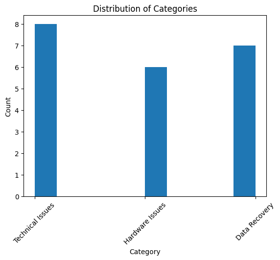

```python
#Create a chart to visualize the distribution of categories

plt.hist(x=final_data['Category'])
plt.xlabel('Category')
plt.ylabel('Count')
plt.title('Distribution of Categories')
plt.xticks(rotation=45)
plt.show()
```

```python
final_data['Priority'].value_counts()   # complete the code to check the distribution of priority
```

```
High      16
Medium     5
Name: Priority, dtype: int64
```

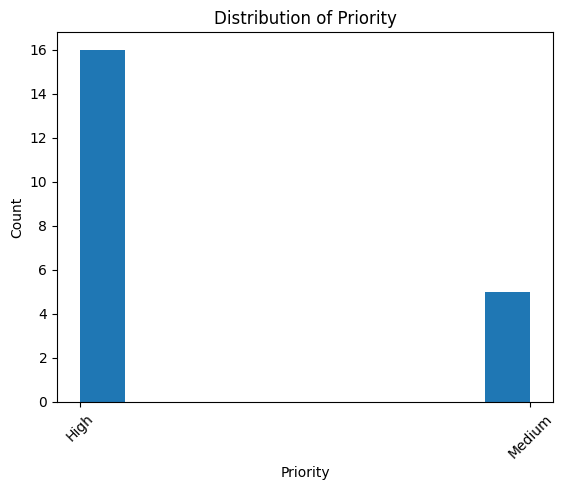

```python
#Create a chart to visualize the distribution of priority

plt.hist(x=final_data['Priority'])
plt.xlabel('Priority')
plt.ylabel('Count')
plt.title('Distribution of Priority')
plt.xticks(rotation=45)
plt.show()
```

```python
final_data['ETA'].value_counts()   # complete the code to check the distribution of ETA
```

```
2-3 Business Days    15
2-4 Hours             3
24-48 Hours           2
1-2 Business Days     1
Name: ETA, dtype: int64
```

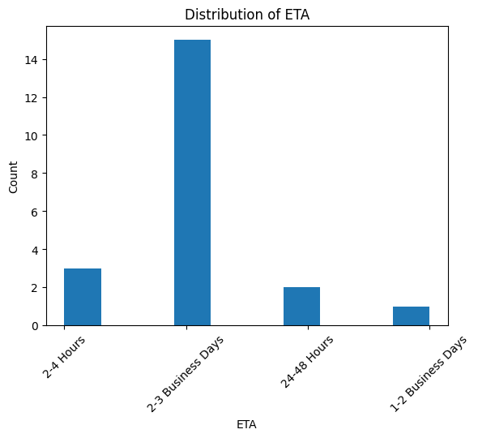

```python
#Create a chart to visualize the distribution of ETA

plt.hist(x=final_data['ETA'])
plt.xlabel('ETA')
plt.ylabel('Count')
plt.title('Distribution of ETA')
plt.xticks(rotation=45)
plt.show()
```

```python
final_data.groupby(['Category', 'Priority']).support_tick_id.count()   # complete the code to check the distribution of priority by categories
```

```
Category          Priority
Data Recovery     High        7
Hardware Issues   High        4
                  Medium      2
Technical Issues  High        5
                  Medium      3
Name: support_tick_id, dtype: int64
```

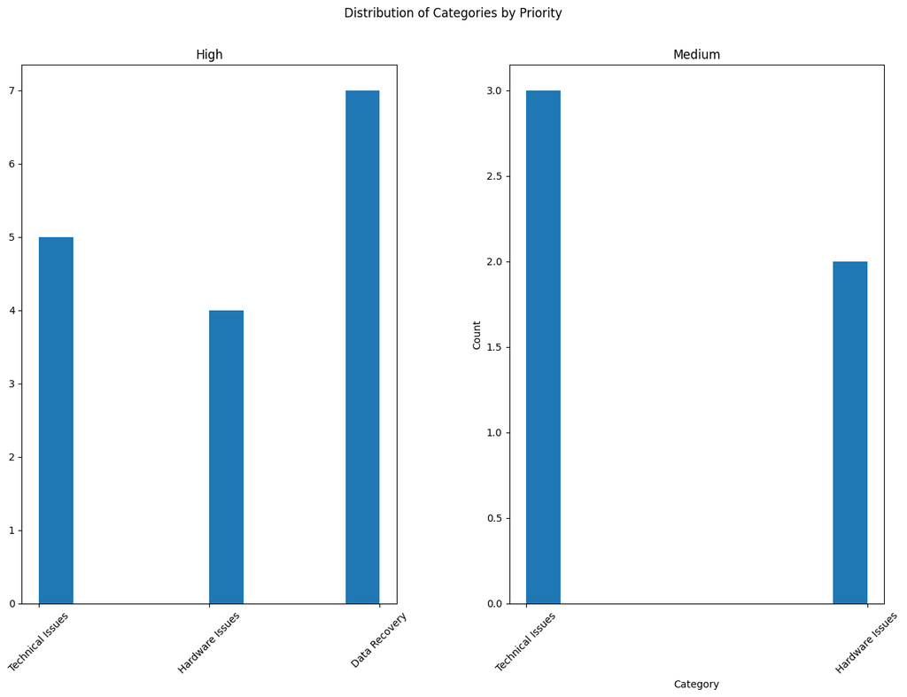

```python
#Create a chart to visualize the distribution of Categories by Priority

plt.figure(figsize=(10, 6))
final_data.hist('Category', by='Priority', xrot=45, figsize=(15,10))
plt.xlabel('Category')
plt.ylabel('Count')
plt.suptitle('Distribution of Categories by Priority')
plt.show()
```

```python
final_data.groupby(['Category', 'ETA']).support_tick_id.count()   # complete the code to check the distribution of ETA by categories
```

```
Category          ETA
Data Recovery     2-3 Business Days    7
Hardware Issues   2-3 Business Days    6
Technical Issues  1-2 Business Days    1
                  2-3 Business Days    2
                  2-4 Hours            3
                  24-48 Hours          2
Name: support_tick_id, dtype: int64
```

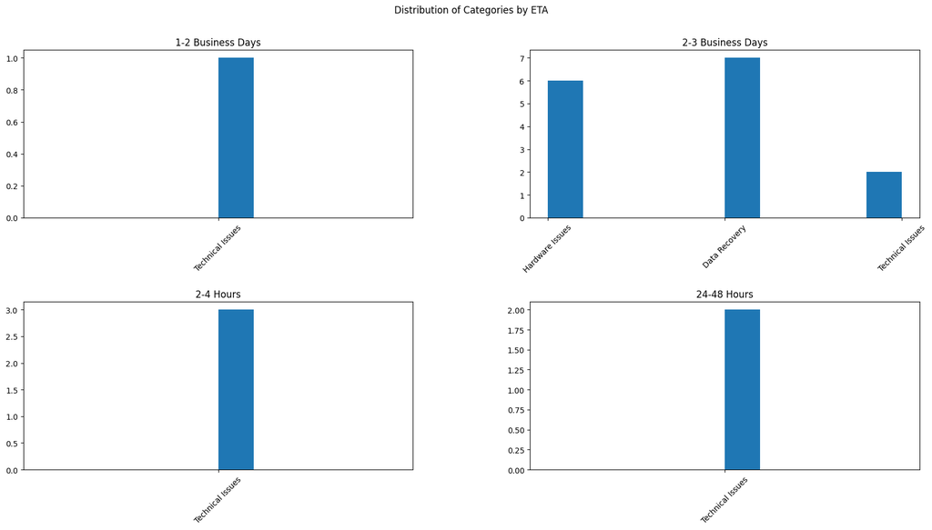

```python
#Create a chart to visualize the distribution of Categories by ETA

final_data.hist('Category', by='ETA', xrot=45, figsize=(20,10))
plt.suptitle('Distribution of Categories by ETA')
plt.show()
```

## **Actionable Insights and Recommendations**

1. **Initial Setup and Training:**
   - Collaborate with data scientists and AI experts to select and fine-tune an LLM model suitable for support ticket categorization.
   - Uptrain the model using historical support ticket data to understand patterns and nuances in ticket categorization.
2. **Define Categories and Tags:**
   - Establish a standardized taxonomy for support ticket categories and tags based on common issues and customer inquiries.
   - Ensure that the model is trained to accurately classify tickets into relevant categories and extract appropriate tags.
3. **Automated Priority Assignment and ETA:**
   - Integrate algorithms within the system to automatically assign priorities to support tickets based on factors such as severity, impact, and SLAs.
   - Implement algorithms to estimate ETA for ticket resolution based on historical data and current workload.
4. **Automated Response Generation:**
   - Develop templates or scripts for generating automated responses to common support ticket categories.
   - Customize responses based on the specific context of each ticket while maintaining consistency and professionalism.
5. **Human-in-the-Loop Feedback Loop:**
   - Implement a feedback loop mechanism where human agents review and validate the categorization, tags, priority, ETA, and automated responses generated by the system.
   - Encourage agents to provide feedback on misclassifications, inaccuracies, or improvements needed in the automated process.
6. **Continuous Monitoring and Improvement:**
   - Regularly monitor the performance of the automated system by analyzing accuracy metrics, feedback from human agents, and customer satisfaction scores.
   - Utilize feedback from human agents to retrain the model, fine-tune algorithms, and improve the accuracy of ticket categorization and response generation.
7. **Gradual Reduction of Manual Efforts:**
   - Track the reduction in manual effort required for support ticket handling over time as the automated system improves.
   - Allocate resources previously spent on manual ticket categorization and response generation to higher-value tasks such as customer engagement and problem-solving.
8. **Regular Evaluation and Adjustment:**
   - Conduct periodic evaluations of the automated system to ensure alignment with evolving customer needs, changes in support processes, and advancements in AI technology.
   - Be prepared to adjust the model, algorithms, or processes based on feedback, performance metrics, and business objectives.
9. **Employee Training and Adoption:**
   - Provide comprehensive training to support agents and other stakeholders on how to effectively utilize and collaborate with the automated ticket categorization system.
   - Foster a culture of trust and transparency around the use of AI tools, emphasizing their role as enablers rather than replacements for human expertise.
10. **Data Security and Compliance:**
    - Implement robust data security measures to protect sensitive customer information processed by the automated system.
    - Ensure compliance with relevant regulations and standards governing data privacy, such as GDPR or CCPA.